# Introduction to Packages

Julia code is organized in packages, and package management is built into the Julia language.

The assumption is that packages are developed with `git` and Julia will clone the whole repository when installing a package.

Users can have their packages registered on a special GitHub repository: METADATA.jl. Dependencies are tracked in the `REQUIRE` file.

```julia
# update the local copy of METADATA
Pkg.update()

# install a registered package
Pkg.add("DataFrames")

# install any other package
#Pkg.clone("https://github.com/leethargo/PipeLayout.jl")

# checkout a branch of a package (default: master)
#Pkg.checkout("PipeLayout")

# list installed packages with versions
Pkg.status()
```

```
INFO: Updating METADATA...
INFO: Updating PipeLayout master...
INFO: Updating SCIP master...
INFO: Computing changes...
```

[output not shown]

[output cut: 45 more lines]

[output not shown]

```
INFO: No packages to install, update or remove
INFO: Package DataFrames is already installed
```

# Creating an index fund

The goal of this project is the definition of an index fund, following the Dow Jones. That is, we want to select few stocks of the index, together with weights, that show a similar behavior to the overall index.

We start with price data of all the Dow Jones stocks from 2016. From the averages prices, we define weights of the stocks to be used

## Loading the price data

The data is provided in a file using comma-separated values and three columns:

```julia
;head dowjones2016.csv
```

```
date,symbol,price
2016-01-04,AAPL,105.349997999999999
2016-01-04,AXP,67.589995999999999
2016-01-04,BA,140.500000000000000
2016-01-04,CAT,67.989998000000000
2016-01-04,CSCO,26.410000000000000
2016-01-04,CVX,88.849997999999999
2016-01-04,DD,63.070000000000000
2016-01-04,DIS,102.980002999999996
2016-01-04,GE,30.709999000000000
```

Julia provides a function to read csv files into arrays:

```julia
?readcsv
```

```
search: readcsv readchomp @threadcall
```

```
readcsv(source, [T::Type]; options...)
```

Equivalent to `readdlm` with `delim` set to comma, and type optionally defined by `T`.

```julia
data = readcsv("dowjones2016.csv")
data[1:5,:]
```

```
5×3 Array{Any,2}:
 "date"        "symbol"     "price"
 "2016-01-04"  "AAPL"    105.35
 "2016-01-04"  "AXP"      67.59
 "2016-01-04"  "BA"      140.5
 "2016-01-04"  "CAT"      67.99
```

But we will use the DataFrames package for easier processing.

```julia
using DataFrames
```

```julia
df = readtable("dowjones2016.csv")
df[1:4, :]
```

|  | date | symbol | price |
| --- | --- | --- | --- |
| 1 | 2016-01-04 | AAPL | 105.349998 |
| 2 | 2016-01-04 | AXP | 67.589996 |
| 3 | 2016-01-04 | BA | 140.5 |
| 4 | 2016-01-04 | CAT | 67.989998 |

We can now access the columns by name:

```julia
df[:price]
```

```
7560-element DataArrays.DataArray{Float64,1}:
 105.35
  67.59
 140.5
  67.99
  26.41
  88.85
  63.07
 102.98
  30.71
 177.14
 131.07
 135.95
  33.99
   ⋮
  58.87
  62.14
  50.83
  32.48
  84.08
 122.42
 160.04
 109.62
  78.02
  53.38
  69.12
  90.26
```

Let's compute mean prices for the stocks, using a groupby-and-aggregate approach.

```julia
avg = by(df, :symbol, d -> DataFrame(avgprice = mean(d[:price])))
avg[1:4, :]
```

|  | symbol | avgprice |
| --- | --- | --- |
| 1 | AAPL | 104.6040078690476 |
| 2 | AXP | 63.79333337698412 |
| 3 | BA | 133.11150809920633 |
| 4 | CAT | 78.69801573015873 |

We can now use these averages to compute weights.

```julia
weights = DataFrame(symbol = avg[:symbol],
                    weight = avg[:avgprice] / sum(avg[:avgprice]))
weights[1:4, :]
```

|  | symbol | weight |
| --- | --- | --- |
| 1 | AAPL | 0.03995967436333611 |
| 2 | AXP | 0.02436962866171713 |
| 3 | BA | 0.05084979654236352 |
| 4 | CAT | 0.030063351736529197 |

We can also *pivot* the table into a two-way format.

```julia
# original dataframe
df[1:4, :]
```

|  | date | symbol | price |
| --- | --- | --- | --- |
| 1 | 2016-01-04 | AAPL | 105.349998 |
| 2 | 2016-01-04 | AXP | 67.589996 |
| 3 | 2016-01-04 | BA | 140.5 |
| 4 | 2016-01-04 | CAT | 67.989998 |

```julia
# two-way table with symbols as columns
#                    rows   columns  data
prices = unstack(df, :date, :symbol, :price)
prices[1:4, 1:4]
```

|  | date | AAPL | AXP | BA |
| --- | --- | --- | --- | --- |
| 1 | 2016-01-04 | 105.349998 | 67.589996 | 140.5 |
| 2 | 2016-01-05 | 102.709999 | 66.550003 | 141.070007 |
| 3 | 2016-01-06 | 100.699997 | 64.419998 | 138.830002 |
| 4 | 2016-01-07 | 96.449997 | 63.84 | 133.009995 |

```julia
joined = join(df, weights, on=:symbol)
joined[1:4, :]
```

|  | date | symbol | price | weight |
| --- | --- | --- | --- | --- |
| 1 | 2016-01-04 | AAPL | 105.349998 | 0.03995967436333611 |
| 2 | 2016-01-05 | AAPL | 102.709999 | 0.03995967436333611 |
| 3 | 2016-01-06 | AAPL | 100.699997 | 0.03995967436333611 |
| 4 | 2016-01-07 | AAPL | 96.449997 | 0.03995967436333611 |

```julia
joined[:contribution] = joined[:weight] .* joined[:price]
joined[1:4, :]
```

|  | date | symbol | price | weight | contribution |
| --- | --- | --- | --- | --- | --- |
| 1 | 2016-01-04 | AAPL | 105.349998 | 0.03995967436333611 | 4.209751614258111 |
| 2 | 2016-01-05 | AAPL | 102.709999 | 0.03995967436333611 | 4.104258113898577 |
| 3 | 2016-01-06 | AAPL | 100.699997 | 0.03995967436333611 | 4.023939088508923 |
| 4 | 2016-01-07 | AAPL | 96.449997 | 0.03995967436333611 | 3.8541104724647446 |

```julia
index = by(joined, :date, d -> DataFrame(value = sum(d[:contribution])))
index[1:4, :]
```

|  | date | value |
| --- | --- | --- |
| 1 | 2016-01-04 | 100.57292879489896 |
| 2 | 2016-01-05 | 100.51142239490156 |
| 3 | 2016-01-06 | 99.01420719993507 |
| 4 | 2016-01-07 | 96.60603263325876 |

## Visualization the time series

```julia
using Plots      # general plotting
pyplot()         # backend, based on Python's matplotlib
```

```
Plots.PyPlotBackend()
```

```julia
x = cumsum(randn(10, 3))
```

```
10×3 Array{Float64,2}:
 0.0967222   1.13685   -0.221413
 2.63506    -0.836293   0.568922
 1.97871     0.380401   0.673628
 0.862146    1.3827    -1.16359
 0.318709    1.72083    0.381898
 2.27183     1.32943   -0.366597
 1.48305     0.657708   1.07946
 1.82443     0.120829  -0.108935
 1.97516    -0.857797  -0.854739
 1.2446     -0.0925    -1.0925
```

Plots will interprete the *columns* of the data as *series* to be plotted independently:

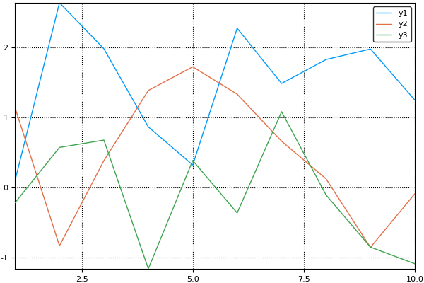

```julia
plot(x)
```

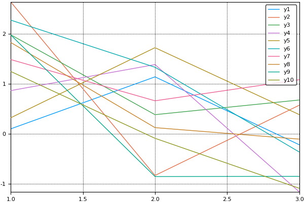

```julia
plot(x')
```

You can also add to existing plots, using the call `plot!`.

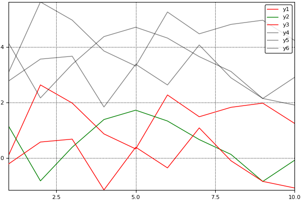

```julia
plot(x, color=[:red :green])
plot!(x + 3, color=:black, alpha=0.5)
```

```julia
using StatPlots  # for DataFrames integration
```

We can set common attributes for several plots using the `with` wrapper:

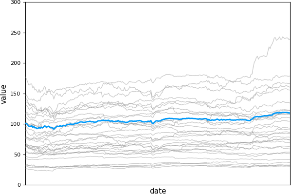

```julia
with(grid=false, legend=false, xticks=false, ylim=(0,300)) do
    plot(df, :date, :price, group=:symbol, color=:grey, alpha=0.4)
    plot!(index, :date, :value, linewidth=2)
end
```

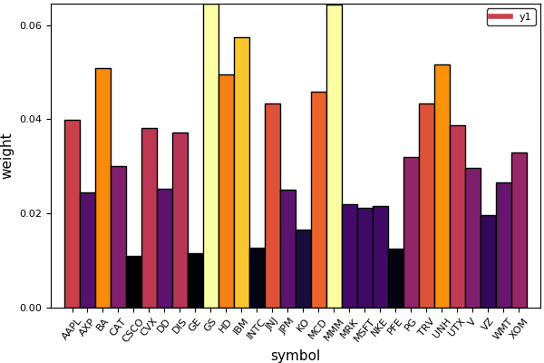

```julia
bar(weights, :symbol, :weight, xrotation=50, color=:weight, grid=false)
```

## Picking stocks

We know come to the decision problem, where we want to pick a small subset of the stocks together with some weights, such that this portfolio has a similar behavior to our overall Dow Jones index.

The model is based on a linear regression over the time series, but we minimize the loss using the L1-norm (absolute value), and allow only a fixed number of weights to take nonzero variable.

A high-level mathematical model might look like this ($w$: weights, $P$: prices, $I$: value of index):

\begin{align*} \text{minimize} \quad & \lVert w^T P - I \rVert_1 \\ \text{subject to} \quad & \lVert w \rVert_0 \le K \end{align*}

Several Julia packages are devoted to this kind of optimization, such as [JuMP](https://github.com/JuliaOpt/JuMP.jl) and [Convex](https://github.com/JuliaOpt/Convex.jl) for modeling, solver backends like [Cbc](https://github.com/JuliaOpt/Cbc.jl) or [SCIP](https://github.com/SCIP-Interfaces/SCIP.jl) and [MathProgBase](https://github.com/JuliaOpt/MathProgBase.jl) as glue. See [JuliaOpt](http://www.juliaopt.org/) for an overview.

```julia
using JuMP # modeling
using Cbc  # solver backend
```

```julia
# preparing data for indexing
syms = [Symbol(s) for s in weights[:symbol]]
days = 1:length(prices[:date])

@show size(syms) size(days);
```

```
size(syms) = (30,)
size(days) = (252,)
```

We will formulate a model that should look quite close to the mathematical notation above.

Note the heavy use of Julia macros to define variables and constraints. The expressions are used as parsed by the Julia language and directly translated to the solver's internal form.

```julia
function find_fund(maxstocks; timelimit=10.0, gaplimit=0.01, lastday=200)
    days = 1:lastday

    fund = Model(solver=CbcSolver(seconds=timelimit, ratioGap=gaplimit))

    # decisions
    @variable(fund, pick[syms], Bin)    # is stock included?
    @variable(fund, weight[syms] ≥ 0)   # what part of the portfolio

    # auxiliary variables
    @variable(fund, Δ⁺[days] ≥ 0) # positive slack
    @variable(fund, Δ⁻[days] ≥ 0) # negative slack

    # fit to Dow Jones index
    for d in days
        @constraint(fund, sum(prices[d,s] * weight[s] for s in syms) == index[d, :value] + Δ⁺[d] - Δ⁻[d])
    end

    # can only use stock if picked
    for s in syms
        @constraint(fund, weight[s] ≤ pick[s])
    end

    # few stocks allowed
    @constraint(fund, sum(pick[s] for s in syms) ≤ maxstocks)

    # minimize the absolute violation (L1 norm)
    @objective(fund, :Min, sum(Δ⁺[d] + Δ⁻[d] for d in days))


    status = solve(fund)
    @show status

    getvalue(weight)
end
```

```
find_fund (generic function with 1 method)
```

```julia
trainingdays = 100
sol = find_fund(3, timelimit=6, lastday=trainingdays)
```

```
WARNING: Not solved to optimality, status: UserLimit
```

```
status = :UserLimit
```

```
weight: 1 dimensions:
[AAPL] = 0.0
[ AXP] = 0.47229506948301675
[  BA] = 0.0
[ CAT] = 0.0
[CSCO] = 0.0
[ CVX] = 0.0
[  DD] = 0.0
[ DIS] = 0.0
[  GE] = 0.0
[  GS] = 0.0
[  HD] = 0.0
[ IBM] = 0.0
[INTC] = 0.0
[ JNJ] = 0.0
[ JPM] = 0.0
[  KO] = 0.0
[ MCD] = 0.0
[ MMM] = 0.31629226616166206
[ MRK] = 0.0
[MSFT] = 0.4061951417784263
[ NKE] = 0.0
[ PFE] = 0.0
[  PG] = 0.0
[ TRV] = 0.0
[ UNH] = 0.0
[ UTX] = 0.0
[   V] = 0.0
[  VZ] = 0.0
[ WMT] = 0.0
[ XOM] = 0.0
```

```julia
solfund = sum(sol[s] * prices[:, s] for s in syms);
```

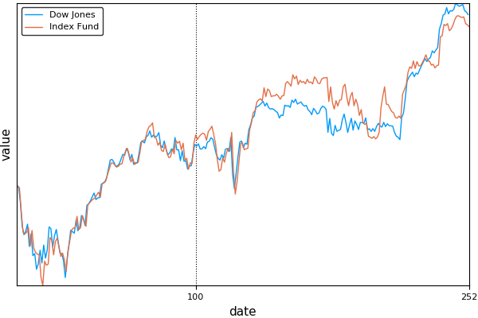

```julia
with(xticks=[0, trainingdays, length(days)], yticks=[]) do
    plot(index, :date, :value, label="Dow Jones")
    plot!(solfund, label="Index Fund")
end
```

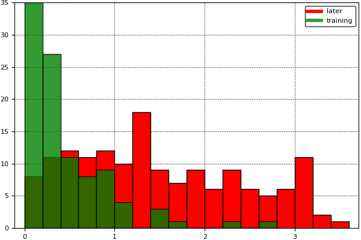

```julia
errors = abs.(index[:value] - solfund)

with(bins=20) do
    histogram(errors[trainingdays:252], label="later", color=:red)
    histogram!(errors[1:trainingdays], alpha=0.8, label="training", color=:green)
end
```